# Stat 475 Final Project

Jacob Baalson

12/4/2021

```r
library(tidyr)
```

```r
library(ggplot2)
library(GGally)
library(fpc)
library(plyr)
library(dplyr)
library(reshape)
library(vegan)
library(caret)
library(MASS)
library(car)
library(biotools)
library(randomForest)
library(DescTools)
library(reshape2)
```

The dataset that I have chosen to do my research over is the sample data that was provided on country economy/social status. When looking over this dataset I have developed 3 research questions that I will be focusing on throughout this report. Does the continent a country is on limit or expand their trade oppurtunities? What countries have the furthest to go to becoming developed? What are the biggest problems that developing countries are facing in becoming developed? With these three questions in mind I have cleaned the dataset to only have the variables that I need for my analysis by removing the variables X.1 and X.

```r
data <- read.csv("sample-data.csv")
##Make Every Categorical Variable a Factor
data$Country <- as.factor(data$Country)
data$Continent <- as.factor(data$Continent)
data$status <- factor(data$status, levels = c("Developing", "Developed"))
str(data)
```

```
## 'data.frame':    1230 obs. of  24 variables:
##  $ X.1                   : int  1 2 3 4 5 6 7 8 9 10 ...
##  $ X                     : int  1 2 3 4 5 6 7 8 9 10 ...
##  $ Country               : Factor w/ 82 levels "Albania","Angola",..: 1 1 1 1 1 1 1 1 1 1 ...
##  $ Date                  : int  2016 2015 2014 2013 2012 2011 2010 2009 2008 2007 ...
##  $ Annual.GDP            : int  11862 11389 13246 12784 12324 12899 11937 12044 12881 10677 ...
##  $ GDP.per.capita        : int  4124 3954 4585 4416 4249 4440 4098 4114 4371 3595 ...
##  $ Debt                  : int  8700 8395 9534 8999 7654 7665 6884 7194 7104 5717 ...
##  $ Debt.Per.Capita       : int  3024 2919 3304 3111 2641 2640 2368 2465 2419 1933 ...
##  $ Deficit...M...        : int  -209 -462 -723 -667 -424 -454 -420 -794 -629 -339 ...
##  $ Expenditure..M...     : num  3458 3459 4202 3732 3477 ...
##  $ Expenditure.Per.Capita: int  1202 1203 1456 1290 1200 1285 1206 1350 1392 1058 ...
##  $ Corruption.Index      : int  39 36 33 31 33 31 33 32 30 29 ...
##  $ Exports               : num  1959 1917 2430 2339 1967 ...
##  $ Exports...GDP         : num  0.165 0.168 0.183 0.183 0.16 ...
##  $ Imports               : num  4613 4302 5222 4920 4879 ...
##  $ Imports...GDP         : num  0.389 0.378 0.395 0.384 0.396 ...
##  $ Population            : num  2876591 2875592 2885796 2892394 2897770 ...
##  $ Fertility.Rate        : num  1.54 1.59 1.73 1.73 1.71 1.65 1.63 1.63 1.58 1.62 ...
##  $ Crude.death.rate      : num  0.0074 0.0078 0.0071 0.0071 0.0072 0.0069 0.0069 0.007 0.0054 0.0049 ...
##  $ HDI                   : num  0.782 0.776 0.773 0.771 0.767 0.752 0.741 0.729 0.724 0.72 ...
##  $ Life.expectancy       : num  78.5 77.9 78.2 77.9 77.2 ...
##  $ CO2.Tons.per.capita   : num  1.6 1.61 1.73 1.6 1.56 1.7 1.56 1.45 1.41 1.41 ...
##  $ Continent             : Factor w/ 6 levels "Africa","Asia",..: 3 3 3 3 3 3 3 3 3 3 ...
##  $ status                : Factor w/ 2 levels "Developing","Developed": 1 1 1 1 1 1 1 1 1 1 ...
```

```r
## Selecting only the variables I choose to use for my analysis
data <- data %>% dplyr::select(-X.1 , -X)
```

The side-by-side bar chart below depicts the average Percent of Annual GDP for Exports and Imports by Continent (2002-2016). This specifically means that I found the average value of imports and exports relative to Annual GDP for a country from a given continent where I included all observations of countries that ranged between 2002 and 2016 in the calculations to find the average values for a country from a given continent. From the side-by-side bar chart below it does seem to some extent that the continent a country is a part of can limit or expand their trade opportunities. Specifically countries in Asia seem to benefit the most from trading, as on average countries in Asia have the highest annual export and import value relative to their annual GDP when compared to the annual export and import values relative to the annual GDP of the average country in other continents. Specifically countries in both Oceania and South America seem to benefit the least from trading, as on average countries in these two continents have the lowest annual export and import values relative to their annual GDP’s when compared to the annual export and import values relative to the annual GDP of the average country in other continents.

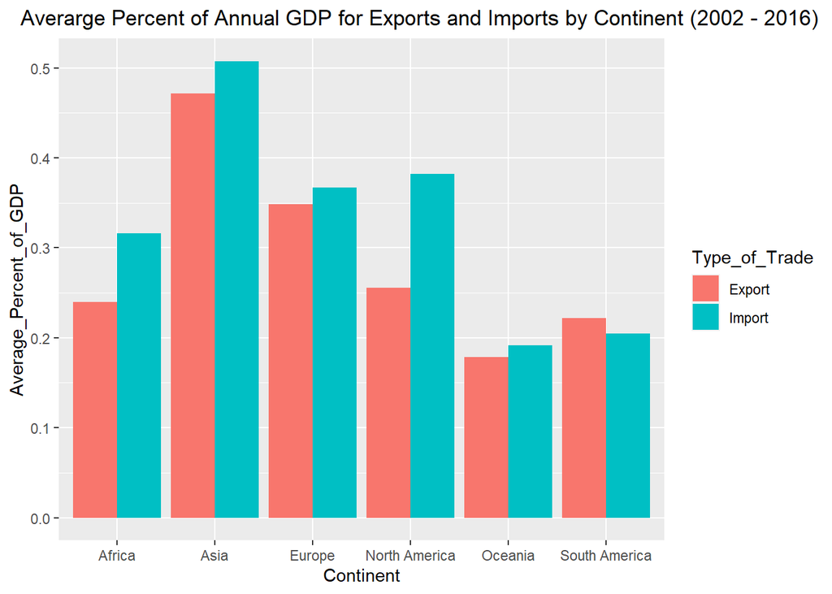

```r
## Create a new dataset with a variable that is the average Exports...GDP for every continent and a variable that is the average Imports...GDP for every continent
AverageImportsExports <- data %>% dplyr::group_by(Continent) %>% dplyr::summarise(Average_Exports...GDP = mean(Exports...GDP), Average_Imports...GDP = mean(Imports...GDP))

##Pivot the AverageImportsExports dataset so that we can make a barchart with the variables
names(AverageImportsExports) <- c("Continent", "Export", "Import")
AverageImportsExports <- pivot_longer(AverageImportsExports, cols = c(Export, Import),names_to = "Type_of_Trade", values_to = "Average_Percent_of_GDP")
AverageImportsExports$'Type_of_Trade' <- as.factor(AverageImportsExports$'Type_of_Trade')



##Side-by-Side bar chart of Average Percent of GDP for Exports and Imports by Country
ggplot(data = AverageImportsExports, aes(x = Continent, y = Average_Percent_of_GDP, fill = Type_of_Trade)) + geom_col(position = "dodge") + ggtitle("Averarge Percent of Annual GDP for Exports and Imports by Continent (2002 - 2016)") + theme(plot.title = element_text(size = 13, hjust = 0.2))
```

To get a sense of some of the countries that have the furthest to go in becoming developed I am first looking at the average HDI of countries between 2002-2016 as it combines both social and financial status of a country. The histogram below depicts the average HDI between 2002 and 2016 of all countries in the data set. This histogram of average HDI is multimodal and left skewed, meaning that a majority of countries have high HDI’s. There does not seem to be any noticable outliers in the histogram that are separated from the rest of the data. From the histogram below it seems that some of the countries that have the furthest to go in becoming developed have an HDI of less than 0.5. The list of these countries include Haiti, Ivory Coast, Madagascar, Malawi, Senegal, Tanzania, and Uganda.

```r
##Find the average HDI between 2002 and 2016 of all countries in the dataset
averageHDI <- data %>% dplyr::group_by(Country) %>% dplyr::summarise(Average_HDI = mean(HDI))
averageHDI
```

```
## # A tibble: 82 x 2
##    Country   Average_HDI
##  * <fct>           <dbl>
##  1 Albania         0.734
##  2 Angola          0.506
##  3 Argentina       0.801
##  4 Australia       0.920
##  5 Austria         0.880
##  6 Belgium         0.899
##  7 Bolivia         0.647
##  8 Botswana        0.645
##  9 Brazil          0.723
## 10 Bulgaria        0.772
## # ... with 72 more rows
```

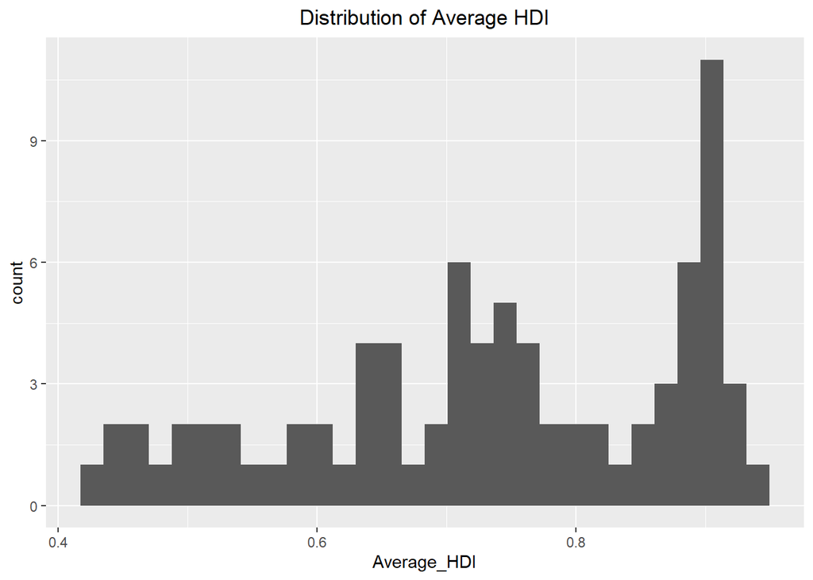

```r
ggplot(averageHDI , aes(x = Average_HDI)) + geom_histogram() + ggtitle("Distribution of Average HDI") + theme(plot.title = element_text(hjust = 0.5))
```

```r
##Countries that have average HDI of less than 0.5
averageHDI[averageHDI$Average_HDI <= 0.5, ]
```

```
## # A tibble: 7 x 2
##   Country     Average_HDI
##   <fct>             <dbl>
## 1 Haiti             0.470
## 2 Ivory Coast       0.437
## 3 Madagascar        0.495
## 4 Malawi            0.424
## 5 Senegal           0.451
## 6 Tanzania          0.479
## 7 Uganda            0.47
```

```r
## Find average of all quantitive variables in the dataset for each country for the observations between 2002-2016
parcoordplot <- data %>% dplyr::select(-Continent, -Date) %>% dplyr::group_by(Country) %>% dplyr::summarise_at(vars(Annual.GDP, GDP.per.capita, Debt, Debt.Per.Capita, Deficit...M..., Expenditure..M..., Expenditure.Per.Capita, Corruption.Index, Exports, Exports...GDP, Imports, Imports...GDP, Population, Fertility.Rate, Crude.death.rate, HDI, Life.expectancy, CO2.Tons.per.capita), mean)

##Rejoin the countries status label with the averaged data
countrystatus <- data %>% dplyr::select(Country, status) %>% dplyr::group_by(Country) %>%  unique()
joinedparcoord <- inner_join(countrystatus, parcoordplot)
joinedparcoord
```

```
## # A tibble: 82 x 20
## # Groups:   Country [82]
##    Country status Annual.GDP GDP.per.capita   Debt Debt.Per.Capita
##    <fct>   <fct>       <dbl>          <dbl>  <dbl>           <dbl>
##  1 Albania Devel~     10409           3549. 6.52e3           2232.
##  2 Angola  Devel~     79566.          3364. 3.20e4           1335.
##  3 Argent~ Devel~    382423.          9284. 2.13e5           5240.
##  4 Austra~ Devel~   1063466.         47866. 2.50e5          10937.
##  5 Austria Devel~    369058.         44048. 2.81e5          33383.
##  6 Belgium Devel~    447794.         41378. 4.48e5          41112.
##  7 Bolivia Devel~     19741.          1952. 8.70e3            873.
##  8 Botswa~ Devel~     11998.          5917. 1.77e3            856.
##  9 Brazil  Devel~   1619999           8294. 1.06e6           5436.
## 10 Bulgar~ Devel~     43695.          5885. 9.53e3           1290.
## # ... with 72 more rows, and 14 more variables: Deficit...M... <dbl>,
## #   Expenditure..M... <dbl>, Expenditure.Per.Capita <dbl>,
## #   Corruption.Index <dbl>, Exports <dbl>, Exports...GDP <dbl>, Imports <dbl>,
## #   Imports...GDP <dbl>, Population <dbl>, Fertility.Rate <dbl>,
## #   Crude.death.rate <dbl>, HDI <dbl>, Life.expectancy <dbl>,
## #   CO2.Tons.per.capita <dbl>
```

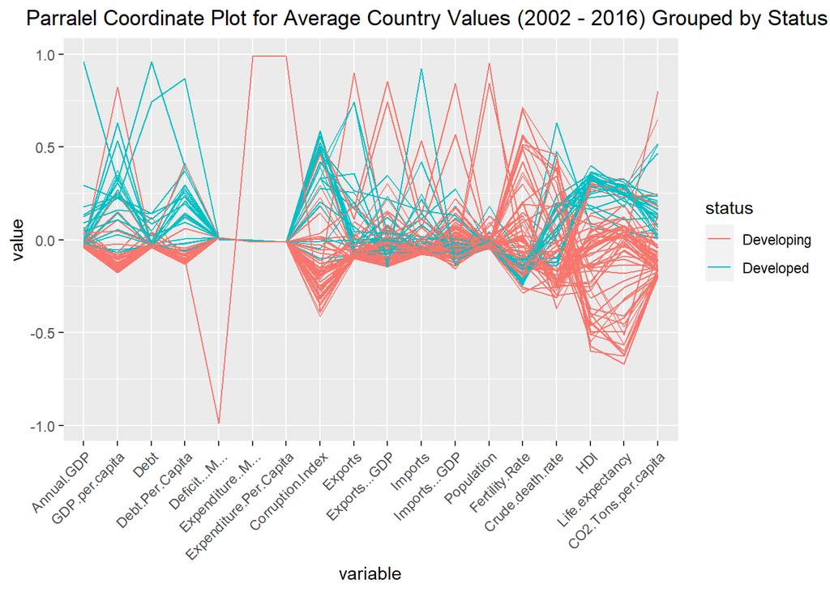

```r
##Create Parralelcoordinate plot where observations are the average values of specific countries over the span of 2002-2016
ggparcoord(data = joinedparcoord, columns = 3:dim(joinedparcoord)[2], groupColumn = 2, scale = "center") + theme(axis.text.x = element_text(angle = 45, hjust = 1), plot.title = element_text(hjust = 0.2)) + ggtitle("Parralel Coordinate Plot for Average Country Values (2002 - 2016) Grouped by Status")
```

To further look into what countries have the furthest to go in becoming developed I decided to use clustering on only the countries that are listed as “developing”. I performed hierarchical clustering using Bray’s distance and Ward’s method as for the reason of not wanting clusters that included only 1 or 2 observations. When looking at the Within/Between Ratio vs. Number of Clusters Plot I found that 2 clusters makes the Within/Between Ratio the highest. I also found that 2 clusters makes the ch index the lowest in the ch index vs. Number of Clusters plot, so the number of clusters that I chose was 2. I then used multidimensional scaling to plot these clusters and found that 3-dimensions is enough to provide good enough representation of the data as the cumulative proportion of the distance captured in 3-dimensions is approximately 0.83. After plotting the 3 dimensional data I was able to see that my clusters did a good job of separating the data into multiple large clusters and not just one cluster that had almost all the observations in it, even with some of the large outliers that I was seeing in the plots of coordinate 3 vs. 1, and the plot of coordinate 3 vs. 2. To see which one of these two clusters of countries was further away from developing I looked to see which cluster had worse average values of the variables I identified as being some of the biggest problems for developing countries using the parallel coordinate plot above. From doing this I found that the cluster that had the furthest to go in becoming developed was cluster 2 as countries in cluster 2 on average had a much worse GDP.per.capita of $4372.735 , Corruption.Index of 32.48376, Crude.death.rate of 0.007688752, HDI of 0.6330291, and Life.expectancy of 67.80159. The average values of cluster 1 tended to be much better in these variables as the average country in cluster 1 had a GDP.per capita of 15700.193, a Corruption.index of 48.96667, a Crude.death.rate of 0.006585741, a HDI of 0.7382519, and a Life.expectancy of 73.82367. From the clustering analysis I can conclude that the countries of Angola, Argentina, Boliva, Brazil, Cameroon, Chile, China, Colombia, Dominican Republic, Ecuador, Egypt, Ghana, Guatemala, Haiti, India, Indonesia, Ivory Coast, Kenya, Madagascar, Malawi, Malaysia, Medxico, Morocoo, Pakistan, Peru, Phillippines, romania, Senegal, South Africa, South Korea, Sri Lanka, tanzania, Thailand, Tunisia, Turkey, Uganda, Venezuela, Vietnam, and Zambia that are in cluster 2 have the furthest to go in becoming developed. The countries in cluster 1 that are still not developed but are closer to becoming developed than countries in cluster 2 include Albania, Botswana, Costa Rica, El Salvador, Honduras, Hong Kong, Israel, Jamaica, Jordan, Luxembourg, Mauritius, Namibia, Nicragua, Panama, Paraguay, Singapore, Trinidad and Tobago, and Uruguay.

```r
## Average values for all countries except continent and data variables
averagecountryvalues <- joinedparcoord

##Take all developed countries out of the data
averagecountryvalues <- averagecountryvalues %>% dplyr::filter(status == "Developing")
##Calculate the distance between the average values of countries
Dist <- vegdist(averagecountryvalues[, c(-1, -2)])
```

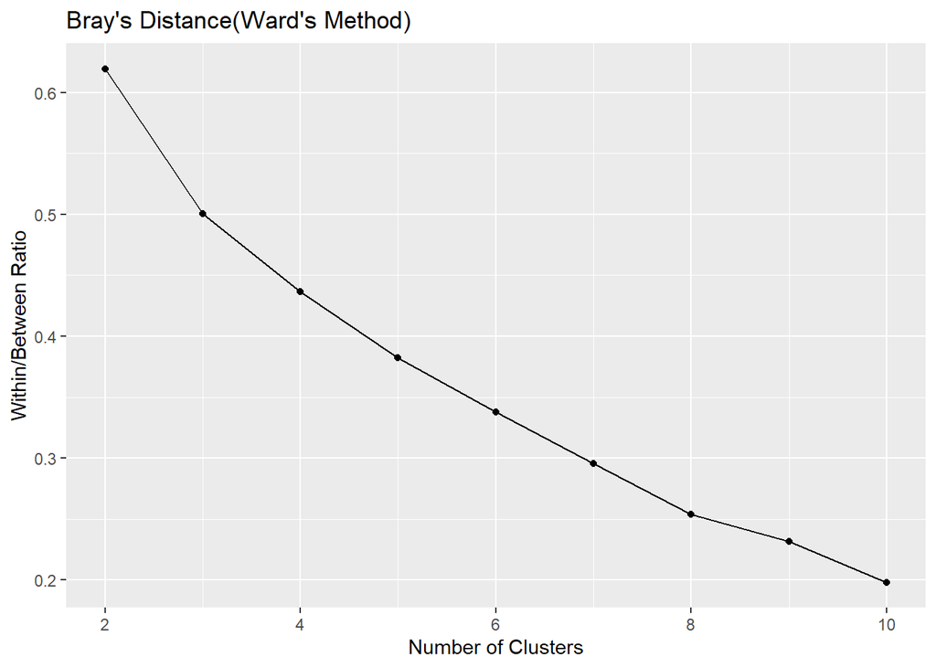

```r
HClust <- hclust(Dist, method = "ward.D2")

## Within/between ratios
WithinBetween <- sapply(2:10, function(x){
  cluster.stats(Dist, clustering = cutree(HClust, x))$wb.ratio
})

qplot(2:10, WithinBetween, geom = c("point", "line"), xlab = "Number of Clusters", ylab = "Within/Between Ratio", main = "Bray's Distance(Ward's Method)")
```